# AWS IoT Analytics | Lab 4 Part 3

When loading data from IoT Analytics datasets, the client should be initialized first:

```python
import boto3

# create IoT Analytics client
client = boto3.client('iotanalytics')
```

This Notebook requires a few basic Python libraries including `pandas`, `numpy`, `mxnet`, `datetime`, `scikit-learn` and `matplotlib`.

```python
import pandas as pd
from datetime import datetime
import numpy as np
import matplotlib.pyplot as plt
import sys
try:
    import sklearn
except ImportError:
    !conda install -c conda-forge --yes --prefix {sys.prefix} scikit-learn
```

Now we can get the data location (URL) for the given dataset and start working with the data. Here is the descriptive statistics (of Vehicle 0) include those that summarize the central tendency, dispersion and shape of a dataset’s distribution, etc. For instance, the means of this vehicle's CO2 and CO emssions levels are 4068 and 56, respectively.

```python
#data = pd.read_csv("https://www.dropbox.com/s/3e943x9of6lk4aq/vehicle0.csv")
#data.head()
url0='https://drive.google.com/file/d/1JwfcextV4UL1gWcNmYtk5SJkfo47qHGh/view?usp=share_link'
url0='https://drive.google.com/uc?id=' + url0.split('/')[-2]
data0 = pd.read_csv(url0)
url1='https://drive.google.com/file/d/1VO5W-8UmS00ZNvgAfaqYh5_UBS5qZ7QV/view?usp=share_link'
url1='https://drive.google.com/uc?id=' + url1.split('/')[-2]
data1 = pd.read_csv(url1)
url2='https://drive.google.com/file/d/1RbLNazgvGUKLS2kAB0ikeEz_QL914RZl/view?usp=share_link'
url2='https://drive.google.com/uc?id=' + url2.split('/')[-2]
data2 = pd.read_csv(url2)
url3='https://drive.google.com/file/d/1CuZzIMXGvksqbT2PXfaArSWQkwZ6A-vo/view?usp=share_link'
url3='https://drive.google.com/uc?id=' + url3.split('/')[-2]
data3 = pd.read_csv(url3)
url4='https://drive.google.com/file/d/1j7rJAPfeVVmoK6p8aX1Lz4oZNZ2ldGIT/view?usp=share_link'
url4='https://drive.google.com/uc?id=' + url4.split('/')[-2]
data4 = pd.read_csv(url4)
#data0.head()
data0.describe()
```

|  | timestep_time | vehicle_CO | vehicle_CO2 | vehicle_HC | vehicle_NOx | vehicle_PMx | vehicle_angle | vehicle_electricity | vehicle_fuel | vehicle_noise | vehicle_pos | vehicle_speed | vehicle_waiting | vehicle_x | vehicle_y |
| --- | --- | --- | --- | --- | --- | --- | --- | --- | --- | --- | --- | --- | --- | --- | --- |
| count | 258.000000 | 258.000000 | 258.000000 | 258.000000 | 258.000000 | 258.000000 | 258.000000 | 258.0 | 258.000000 | 258.000000 | 258.000000 | 258.000000 | 258.0 | 258.000000 | 258.000000 |
| mean | 128.500000 | 56.042442 | 4067.863372 | 0.353333 | 1.643798 | 0.081744 | 115.952481 | 0.0 | 1.748605 | 67.770155 | 154.356434 | 17.911473 | 0.0 | 18059.564302 | 26247.744186 |
| std | 74.622383 | 74.315887 | 4550.772411 | 0.448769 | 1.928542 | 0.104168 | 139.880854 | 0.0 | 1.956170 | 5.778911 | 193.120170 | 7.474554 | 0.0 | 249.979884 | 1217.792271 |
| min | 0.000000 | 0.000000 | 0.000000 | 0.000000 | 0.000000 | 0.000000 | 0.020000 | 0.0 | 0.000000 | 47.140000 | 0.030000 | 4.390000 | 0.0 | 17829.880000 | 24533.120000 |
| 25% | 64.250000 | 0.000000 | 0.000000 | 0.000000 | 0.000000 | 0.000000 | 0.360000 | 0.0 | 0.000000 | 64.907500 | 27.107500 | 12.790000 | 0.0 | 17834.470000 | 24968.037500 |
| 50% | 128.500000 | 9.705000 | 2926.925000 | 0.110000 | 1.040000 | 0.030000 | 41.485000 | 0.0 | 1.260000 | 68.560000 | 90.135000 | 14.700000 | 0.0 | 17919.150000 | 26081.280000 |
| 75% | 192.750000 | 105.497500 | 7083.862500 | 0.637500 | 2.847500 | 0.140000 | 272.492500 | 0.0 | 3.047500 | 72.590000 | 198.645000 | 23.797500 | 0.0 | 18276.697500 | 27682.682500 |
| max | 257.000000 | 432.720000 | 23476.300000 | 2.560000 | 10.330000 | 0.580000 | 359.950000 | 0.0 | 10.090000 | 80.010000 | 958.090000 | 29.400000 | 0.0 | 18549.200000 | 27914.230000 |

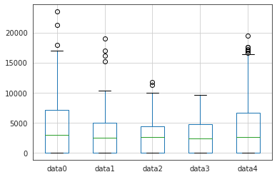

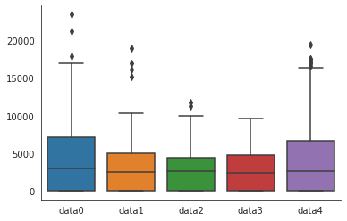

```python
import seaborn as sns

combined_dfs = pd.DataFrame({'data0': data0['vehicle_CO2'],
                             'data1': data1['vehicle_CO2'],
                             'data2': data2['vehicle_CO2'],
                             'data3': data3['vehicle_CO2'],
                             'data4': data4['vehicle_CO2']})
combined_dfs.boxplot()
plt.show()
sns.set_style('white')
#sns.boxplot(data=combined_dfs, palette='flare')
sns.boxplot(data=combined_dfs)
sns.despine()
plt.show()
```

For example, here are the mean and median of the CO2 emission from Vehicle 0:

```python
mean = data0['vehicle_CO2'].mean()
median = data0['vehicle_CO2'].median()

print(f'Mean for CO2 Emission is {mean}')
print(f'Median for CO2 Emission is {median}')
```

```
Mean for CO2 Emission is 4067.8633720930234
Median for CO2 Emission is 2926.925
```

We want to see how the emission measurements and fuel interact with each other by plotting a correlation matrix. This will tell us if a relationship exists between any of the values in our data set. If we have measurements that are tightly correlated, then they carry the same information and we can discard one or more of the values without losing information. Below is the data taken from Vehicle 1 and 2.

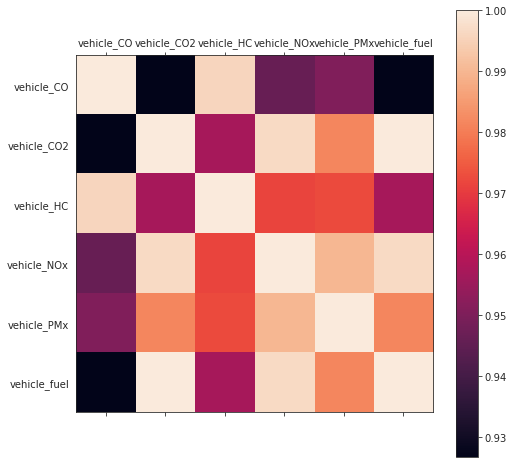

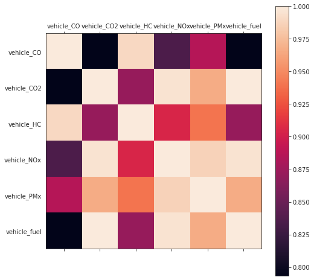

```python
cor_cols = ['vehicle_CO', 'vehicle_CO2', 'vehicle_HC', 'vehicle_NOx', 'vehicle_PMx', 'vehicle_fuel']

# plot correlation matrix
#plt.matshow(data0.loc[:, cor_cols].corr())
plt.matshow(data1.loc[:, cor_cols].corr(method='pearson'))
plt.xticks(range(len(cor_cols)), cor_cols)
plt.yticks(range(len(cor_cols)), cor_cols)
plt.colorbar()
fig = plt.gcf()
fig.set_size_inches(8, 8)
plt.plot()

plt.matshow(data2.loc[:, cor_cols].corr('pearson'))
plt.xticks(range(len(cor_cols)), cor_cols)
plt.yticks(range(len(cor_cols)), cor_cols)
plt.colorbar()
fig = plt.gcf()
fig.set_size_inches(8, 8)

plt.show()
```

On a correlation matrix, a correlation of 1 indicates that the values or variables are self-similar, i.e. the same, where a correlation of -1 indicates that the variables are opposites. A correation score of 0 indicates that there is no relationship between the variables. For our sample data set, there are strong correlations between these measurements. Here is another figure that shows the correlations between two measurements. We also add the measurement of the vehicles' noise levels.

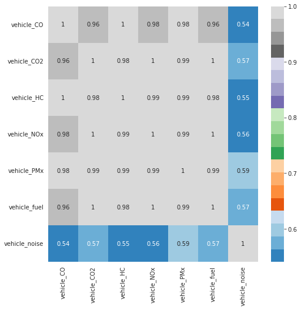

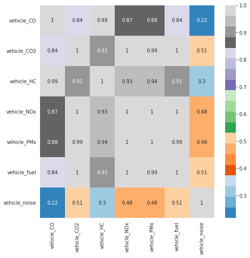

```python
plt.figure(figsize=(8,8))
cor_cols = ['vehicle_CO', 'vehicle_CO2', 'vehicle_HC', 'vehicle_NOx', 'vehicle_PMx', 'vehicle_fuel', 'vehicle_noise']
corr0 = data0.loc[:, cor_cols].corr(method='pearson')
sns.heatmap(corr0, annot=True,cmap='tab20c')
plt.plot()

plt.figure(figsize=(8,8))
corr4 = data4.loc[:, cor_cols].corr(method='pearson')
sns.heatmap(corr4, annot=True,cmap='tab20c')
plt.show()
```

To explore our data set further, let's take a look at a pairwise scatter matrix for more insights. The scatter matrix plots each variable or value against each other. This allows us to look for linear relationships between the variables which, again, would allow us to simplify our forecasting model.

[figure not shown]

```python
plt.figure(figsize=(10,5))
sns.pairplot(data0.loc[:, cor_cols],kind="reg")
#sns.pairplot(data0.loc[:, cor_cols])
plt.show()
```

As the fuel increases, the noise level aslo increases.

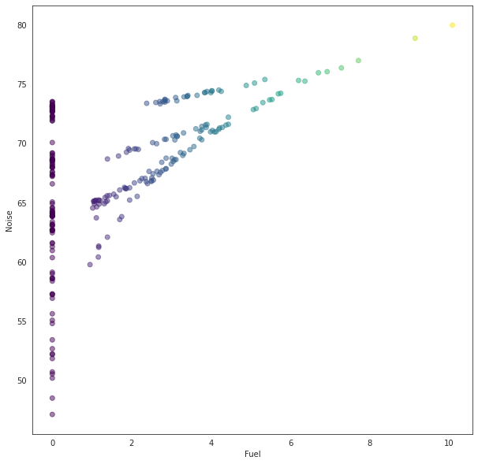

```python
plt.figure(figsize=(10,10))
#data0.plot.scatter(x='vehicle_fuel', y='vehicle_noise', alpha=0.5, cmap='viridis')
plt.scatter(data0['vehicle_fuel'], data0['vehicle_noise'], alpha=0.5, cmap='viridis', c=data0['vehicle_fuel'])
plt.xlabel("Fuel")
plt.ylabel("Noise")
plt.show()
```